# Untitled

Z. Palmore

## Introduction

```r
# Packages
library(tidyverse)
library(kableExtra)
library(fpp2)
# Data source
data <- read.csv("https://raw.githubusercontent.com/palmorezm/msds/main/Predictive%20Analytics/Projects/Project1/project1data.csv")
# data <- data %>%
#   rename(SeriesInd = ï..SeriesInd)
head(data, 5)
```

|  | ï..SeriesInd | group | Var01 | Var02 | Var03 | Var05 | Var07 |
| --- | --- | --- | --- | --- | --- | --- | --- |
| 1 | 40669 | S03 | 30.64286 | 123432400 | 30.34 | 30.49 | 30.57286 |
| 2 | 40669 | S02 | 10.28000 | 60855800 | 10.05 | 10.17 | 10.28000 |
| 3 | 40669 | S01 | 26.61000 | 10369300 | 25.89 | 26.20 | 26.01000 |
| 4 | 40669 | S06 | 27.48000 | 39335700 | 26.82 | 27.02 | 27.32000 |
| 5 | 40669 | S05 | 69.26000 | 27809100 | 68.19 | 68.72 | 69.15000 |

```r
data <- data %>% rename(SeriesInd = ï..SeriesInd)
```

We create forecasts for two preselected variables within each of six predetermined groups. These groups are denoted S01, S02, S03, S04, S05, and S06 respectively. There are five variables within each group that we have to work with. They are Var01, Var02, Var03, Var05, and Var07 respectively. Our date variable ‘SeriesInd,’ is displayed in its numeric serial number form calculated with Excel. Although we do not know what the variables stand for, we can develop models to try and forecast their behavior. This chart contains a breakdown of which variables are forecast in each group.

```r
# Chart
varsbygroup <- data.frame(matrix(c("S01", "S02", "S03",
                                   "S04", "S05", "S06",
                                   "Var01", "Var02", "Var05",
                                   "Var01", "Var02", "Var05",
                                   "Var02", "Var03", "Var07",
                                   "Var02", "Var03", "Var07"),
                                 nrow = 6, ncol=3))
colnames(varsbygroup) <- c("Group", "Variable1", "Variable2")
varsbygroup %>%
  kbl(booktabs = T) %>%
  kable_styling(latex_options = c("striped", "HOLD_position", "scale_down"), full_width = T)
```

| Group | Variable1 | Variable2 |
| --- | --- | --- |
| S01 | Var01 | Var02 |
| S02 | Var02 | Var03 |
| S03 | Var05 | Var07 |
| S04 | Var01 | Var02 |
| S05 | Var02 | Var03 |
| S06 | Var05 | Var07 |

```r
# Grouping
S01 <- data %>%
  filter(group == "S01")
S02 <- data %>%
  filter(group == "S02")
S03 <- data %>%
  filter(group == "S03")
S04 <- data %>%
  filter(group == "S04")
S05 <- data %>%
  filter(group == "S05")
S06 <- data %>%
  filter(group == "S06")

# Imputation by function - missing something? lapply/sapply may work
soximp <- function(df){
  for (i in colnames(df)){
    if (sum(is.na(df[[i]])) !=0){
      df[[i]][is.na(df[[i]])] <- median(df[[i]], na.rm=TRUE)
    }
  }
}

# Imputation loops for each group by median
for (i in colnames(S01)){
  if (sum(is.na(S01[[i]])) != 0){
    S01[[i]][is.na(S01[[i]])] <- median(S01[[i]], na.rm = TRUE)
  }
}
for (i in colnames(S02)){
  if (sum(is.na(S02[[i]])) != 0){
    S02[[i]][is.na(S02[[i]])] <- median(S02[[i]], na.rm = TRUE)
  }
}
for (i in colnames(S03)){
  if (sum(is.na(S03[[i]])) != 0){
    S03[[i]][is.na(S03[[i]])] <- median(S03[[i]], na.rm = TRUE)
  }
}
for (i in colnames(S04)){
  if (sum(is.na(S04[[i]])) != 0){
    S04[[i]][is.na(S04[[i]])] <- median(S04[[i]], na.rm = TRUE)
  }
}
for (i in colnames(S05)){
  if (sum(is.na(S05[[i]])) != 0){
    S05[[i]][is.na(S05[[i]])] <- median(S05[[i]], na.rm = TRUE)
  }
}
for (i in colnames(S06)){
  if (sum(is.na(S06[[i]])) != 0){
    S06[[i]][is.na(S06[[i]])] <- median(S06[[i]], na.rm = TRUE)
  }
}
```

Before we begin, the data is filtered to extract each time series by group. This isolates the Var01, Var02, Var03, Var05, and Var07 variables associated with groups S01, S02, and so on. Then, with each group and its respective variables’ behavior isolated, we clean and adjust the data to make use of it in the analysis. Once we determine the most appropriate models to forecast the proper variable in each group, we evaluate the results of our predictions. Our final forecasts are captured in the excel spreadsheet attached.

## Analysis

We began by addressing missing values. Given 10,572 observations, about 8% of each variable was missing. Several methods were tried to address this but the best were Kalman smoothing and simple imputation by the median of each ‘Var0X’ variable to fill in where appropriate. The ‘SeriesInd’ numeric date was also converted from its serial number form to a common date-time series. We then examined each group’s variables separately.

```r
# library(fpp2)

#S01
S01<-subset(data, group == "S01", select = c(SeriesInd, Var01, Var02))%>%
  mutate(date=as.Date(SeriesInd, origin = "1905-01-01"))
summary(S01)
```

```
##    SeriesInd         Var01           Var02               date
##  Min.   :40669   Min.   :23.01   Min.   : 1339900   Min.   :2016-05-07
##  1st Qu.:41304   1st Qu.:29.85   1st Qu.: 5347550   1st Qu.:2018-01-31
##  Median :41946   Median :35.66   Median : 7895050   Median :2019-11-05
##  Mean   :41945   Mean   :39.41   Mean   : 8907092   Mean   :2019-11-03
##  3rd Qu.:42586   3rd Qu.:48.70   3rd Qu.:11321675   3rd Qu.:2021-08-06
##  Max.   :43221   Max.   :62.31   Max.   :48477500   Max.   :2023-05-03
##                  NA's   :142     NA's   :140
```

```r
# Subset Var01 and Var02 from S01.
S01_Var01<-S01 %>%select(Var01)
S01_Var01<-S01_Var01[1:1625,]


S01_Var02<-S01 %>%select(Var02)
S01_Var02<-S01_Var02[1:1625,]


#S02
S02<-subset(data, group == "S02", select = c(SeriesInd, Var02, Var03))%>%
  mutate(date=as.Date(SeriesInd, origin = "1905-01-01"))
summary(S02)
```

```
##    SeriesInd         Var02               Var03            date
##  Min.   :40669   Min.   :  7128800   Min.   : 8.82   Min.   :2016-05-07
##  1st Qu.:41304   1st Qu.: 27880300   1st Qu.:11.82   1st Qu.:2018-01-31
##  Median :41946   Median : 39767500   Median :13.76   Median :2019-11-05
##  Mean   :41945   Mean   : 50633098   Mean   :13.68   Mean   :2019-11-03
##  3rd Qu.:42586   3rd Qu.: 59050900   3rd Qu.:15.52   3rd Qu.:2021-08-06
##  Max.   :43221   Max.   :480879500   Max.   :38.28   Max.   :2023-05-03
##                  NA's   :140         NA's   :144
```

```r
# Subset Var02 and Var03 from S02.
S02_Var02<-S02 %>%select(Var02)
S02_Var02<-S02_Var02[1:1625,]


S02_Var03<-S02 %>%select(Var03)
S02_Var03<-S02_Var03[1:1625,]



#S03
S03<-subset(data, group == "S03", select = c(SeriesInd, Var05, Var07))%>%
  mutate(date=as.Date(SeriesInd, origin = "1905-01-01"))
summary(S03)
```

```
##    SeriesInd         Var05            Var07             date
##  Min.   :40669   Min.   : 27.48   Min.   : 27.44   Min.   :2016-05-07
##  1st Qu.:41304   1st Qu.: 53.30   1st Qu.: 53.46   1st Qu.:2018-01-31
##  Median :41946   Median : 75.59   Median : 75.71   Median :2019-11-05
##  Mean   :41945   Mean   : 76.90   Mean   : 76.87   Mean   :2019-11-03
##  3rd Qu.:42586   3rd Qu.: 98.55   3rd Qu.: 98.61   3rd Qu.:2021-08-06
##  Max.   :43221   Max.   :134.46   Max.   :133.00   Max.   :2023-05-03
##                  NA's   :144      NA's   :144
```

```r
# Subset Var05 and Var07 from S03.
S03_Var05<-S03 %>%select(Var05)
S03_Var05<-S03_Var05[1:1625,]


S03_Var07<-S03 %>%select(Var07)
S03_Var07<-S03_Var07[1:1625,]
```

```r
library(imputeTS)
# Summarize the subset data.

summary(S01_Var01)
```

```
##    Min. 1st Qu.  Median    Mean 3rd Qu.    Max.    NA's
##   23.01   29.85   35.66   39.41   48.70   62.31       5
```

```r
summary(S01_Var02)
```

```
##     Min.  1st Qu.   Median     Mean  3rd Qu.     Max.     NA's
##  1339900  5347550  7895050  8907092 11321675 48477500        3
```

```r
summary(S02_Var02)
```

```
##      Min.   1st Qu.    Median      Mean   3rd Qu.      Max.      NA's
##   7128800  27880300  39767500  50633098  59050900 480879500         3
```

```r
summary(S02_Var03)
```

```
##    Min. 1st Qu.  Median    Mean 3rd Qu.    Max.    NA's
##    8.82   11.82   13.76   13.68   15.52   38.28       7
```

```r
summary(S03_Var07)
```

```
##    Min. 1st Qu.  Median    Mean 3rd Qu.    Max.    NA's
##   27.44   53.46   75.71   76.87   98.61  133.00       7
```

```r
summary(S03_Var05)
```

```
##    Min. 1st Qu.  Median    Mean 3rd Qu.    Max.    NA's
##   27.48   53.30   75.59   76.90   98.55  134.46       7
```

```r
# according to the summary of subsets,
# S01_Var01 has 5 NAs
# S01_Var02 has 3 NAs
# S02_Var02 has 3 NAs
# S02_Var03 has 7 NAs
# S03_Var07 has 7 NAs
# S03_Var05 has 7 NAs

# Using Kalman Smoothing to impute NAs.
S01_Var01<-na_kalman(S01_Var01)
S01_Var02<-na_kalman(S01_Var02)
S02_Var02<-na_kalman(S02_Var02)
S02_Var03<-na_kalman(S02_Var03)
S03_Var05<-na_kalman(S03_Var05)
S03_Var07<-na_kalman(S03_Var07)

summary(S01_Var01)
```

```
##    Min. 1st Qu.  Median    Mean 3rd Qu.    Max.
##   23.01   29.85   35.72   39.47   48.76   62.38
```

```r
summary(S01_Var02)
```

```
##     Min.  1st Qu.   Median     Mean  3rd Qu.     Max.
##  1339900  5350400  7874900  8901799 11312300 48477500
```

```r
summary(S02_Var02)
```

```
##      Min.   1st Qu.    Median      Mean   3rd Qu.      Max.
##   7128800  27829000  39737500  50581126  59017900 480879500
```

```r
summary(S02_Var03)
```

```
##    Min. 1st Qu.  Median    Mean 3rd Qu.    Max.
##    8.82   11.82   13.75   13.68   15.52   38.28
```

```r
summary(S03_Var07)
```

```
##    Min. 1st Qu.  Median    Mean 3rd Qu.    Max.
##   27.44   53.56   75.77   76.95   98.46  133.00
```

```r
summary(S03_Var05)
```

```
##    Min. 1st Qu.  Median    Mean 3rd Qu.    Max.
##   27.48   53.35   75.70   76.99   98.57  134.46
```

```r
# NA  no longer exists
ts_S01_Var01<-ts(S01_Var01)
ts_S01_Var02<-ts(S01_Var02)
ts_S02_Var02<-ts(S02_Var02)
ts_S02_Var03<-ts(S02_Var03)
ts_S03_Var05<-ts(S03_Var05)
ts_S03_Var07<-ts(S03_Var07)

str(ts_S01_Var01)
```

```
##  Time-Series [1:1625] from 1 to 1625: 26.6 26.3 26 25.8 26.3 ...
```

```r
str(ts_S01_Var02)
```

```
##  Time-Series [1:1625] from 1 to 1625: 10369300 10943800 8933800 10775400 12875600 ...
```

```r
str(ts_S02_Var02)
```

```
##  Time-Series [1:1625] from 1 to 1625: 6.09e+07 2.16e+08 2.00e+08 1.30e+08 1.30e+08 ...
```

```r
str(ts_S02_Var03)
```

```
##  Time-Series [1:1625] from 1 to 1625: 10.1 10.4 11.1 11.3 11.5 ...
```

```r
str(ts_S03_Var05)
```

```
##  Time-Series [1:1625] from 1 to 1625: 30.5 30.7 30.6 30.2 30 ...
```

```r
str(ts_S03_Var07)
```

```
##  Time-Series [1:1625] from 1 to 1625: 30.6 30.6 30.1 30.1 30.3 ...
```

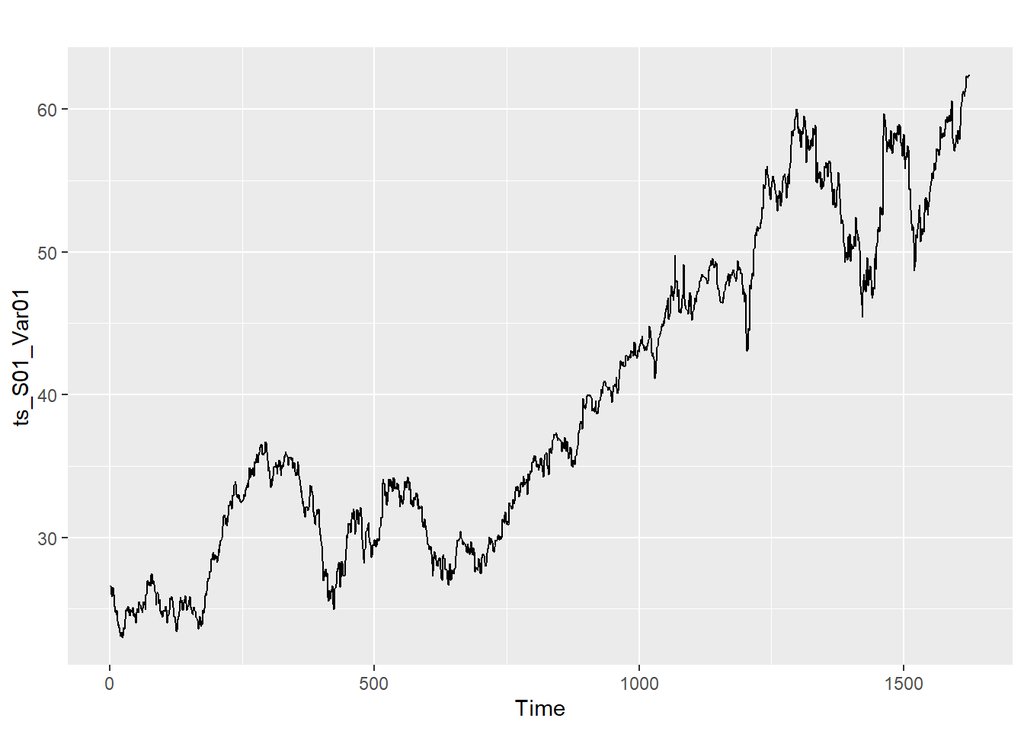

```r
autoplot(ts_S01_Var01)
```

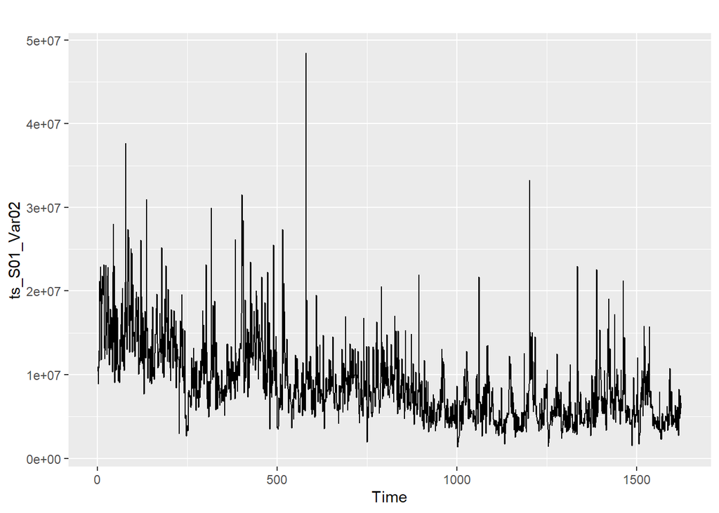

```r
autoplot(ts_S01_Var02)
```

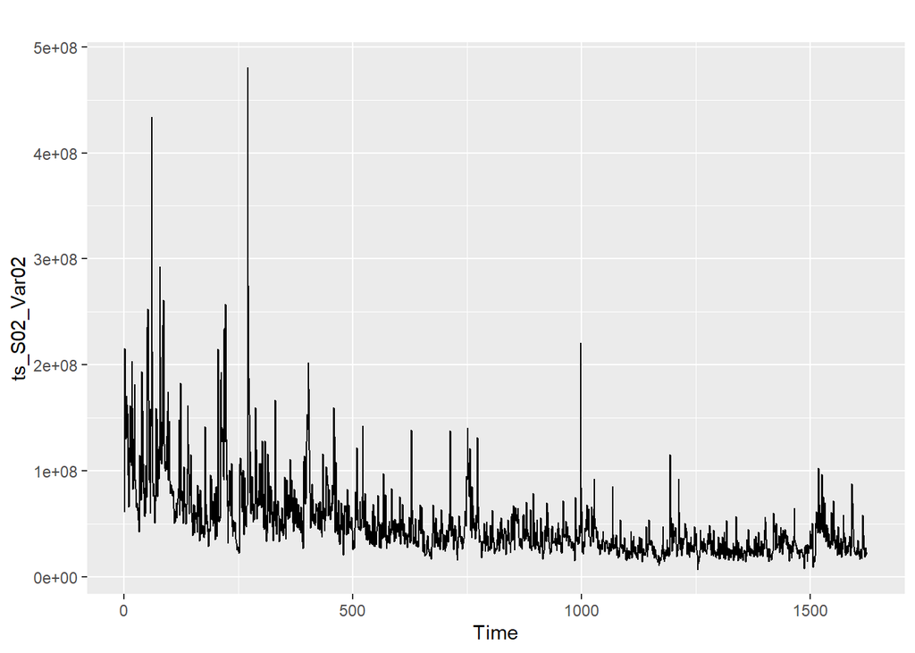

```r
autoplot(ts_S02_Var02)
```

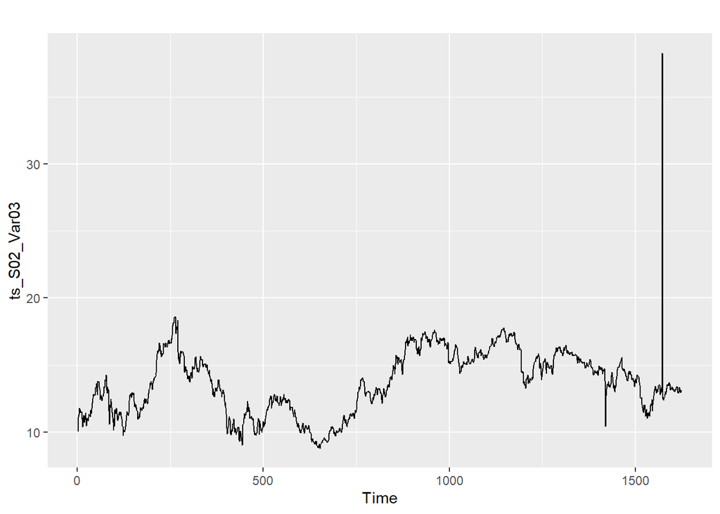

```r
autoplot(ts_S02_Var03)
```

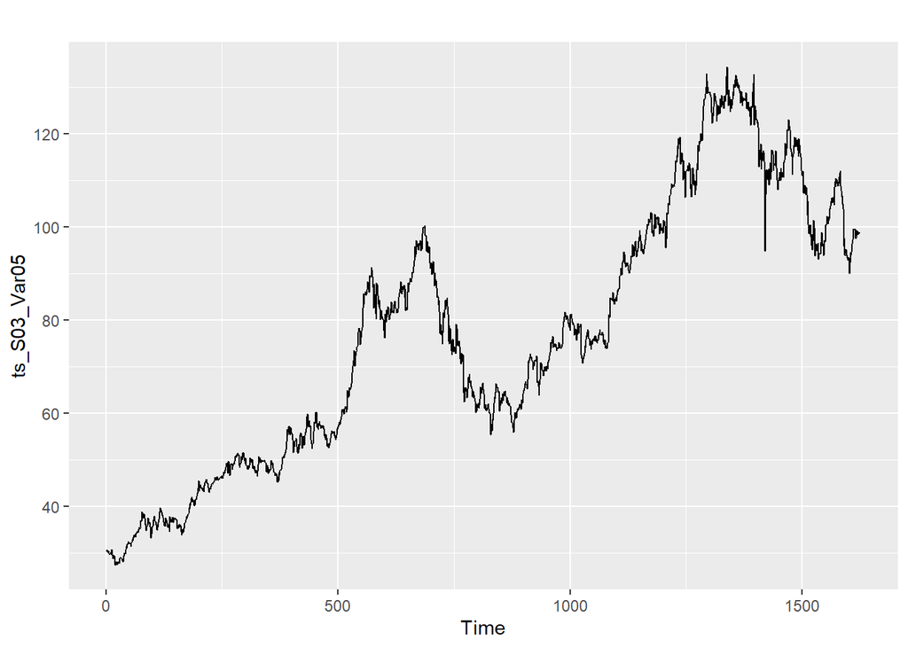

```r
autoplot(ts_S03_Var05)
```

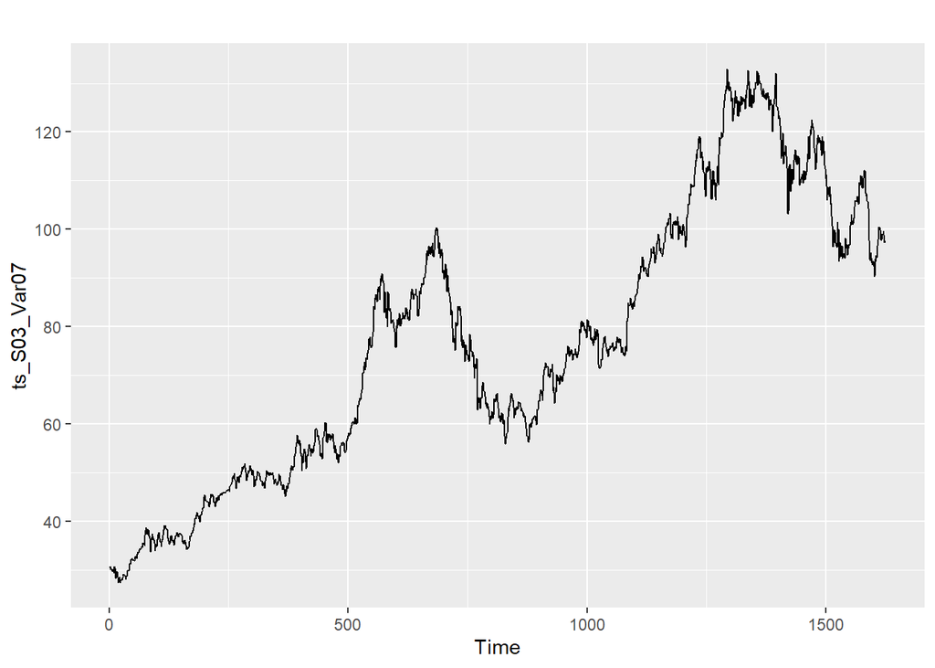

```r
autoplot(ts_S03_Var07)
```

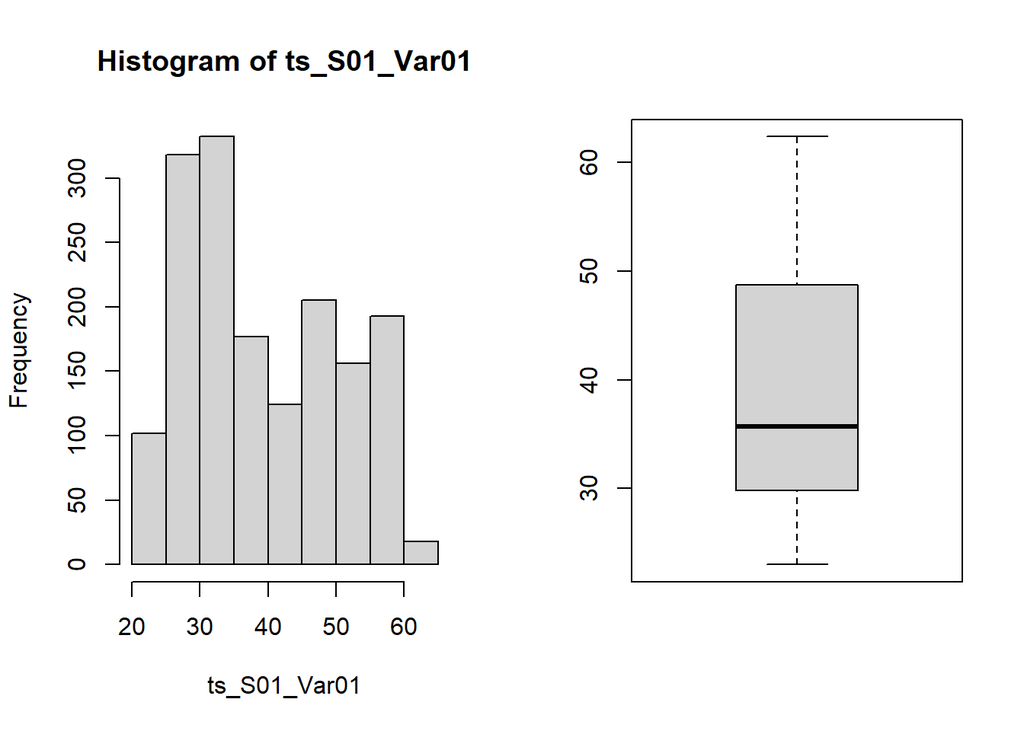

```r
par(mfrow = c(1,2))
hist(ts_S01_Var01)
boxplot(ts_S01_Var01)
```

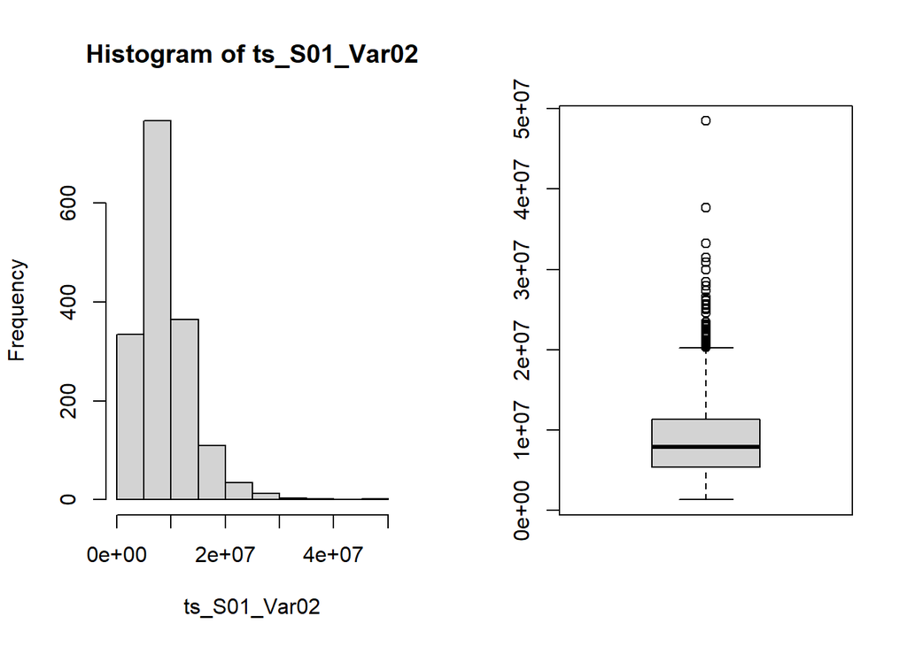

```r
par(mfrow = c(1,2))
hist(ts_S01_Var02)
boxplot(ts_S01_Var02)
```

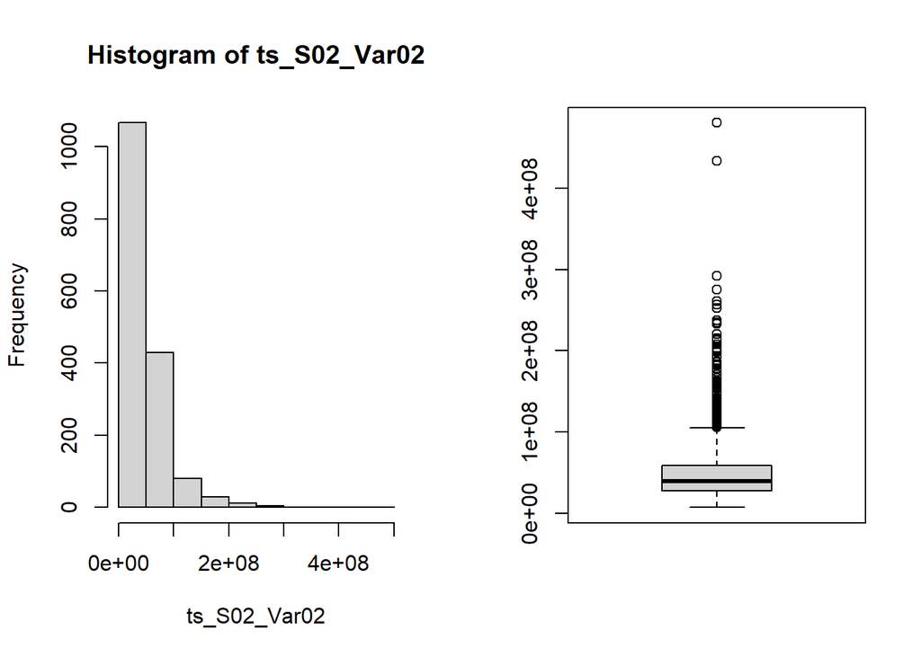

```r
par(mfrow = c(1,2))
hist(ts_S02_Var02)
boxplot(ts_S02_Var02)
```

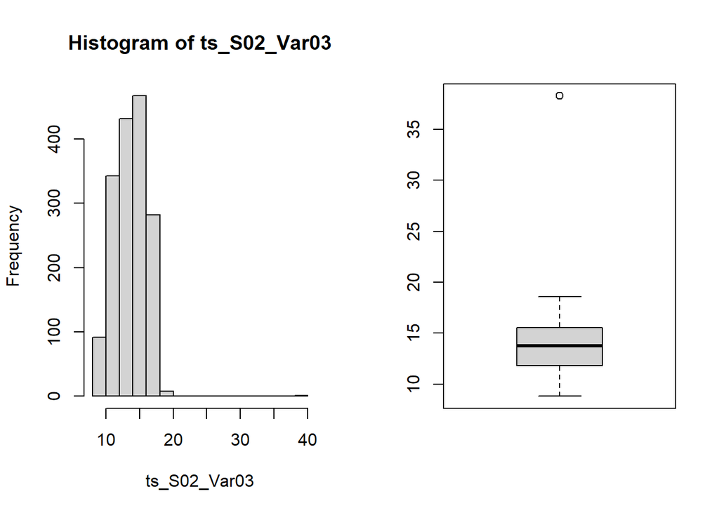

```r
par(mfrow = c(1,2))
hist(ts_S02_Var03)
boxplot(ts_S02_Var03)
```

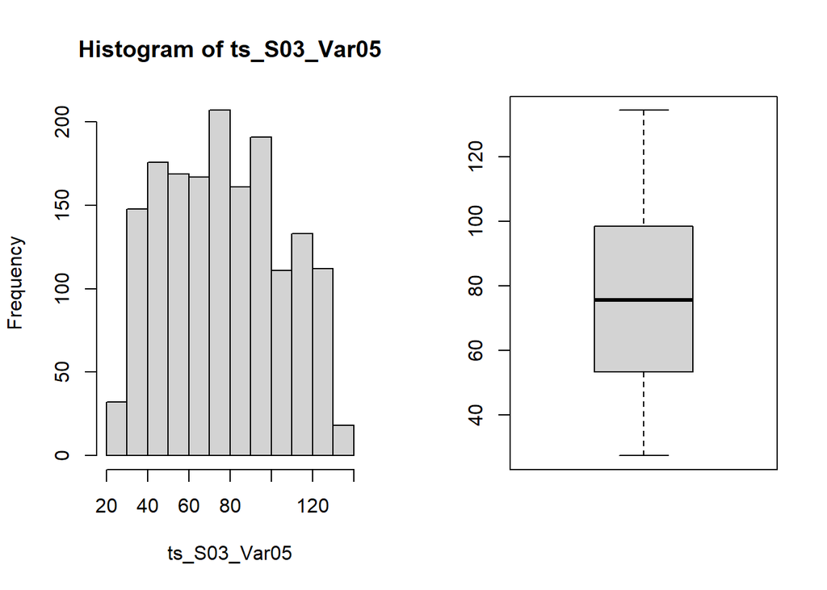

```r
par(mfrow = c(1,2))
hist(ts_S03_Var05)
boxplot(ts_S03_Var05)
```

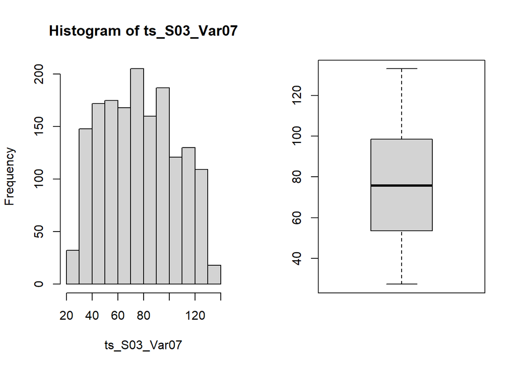

```r
par(mfrow = c(1,2))
hist(ts_S03_Var07)
boxplot(ts_S03_Var07)
```

Additionally, all but group S03 of the histograms exhibited right skewness, and Var02 and Var03 had outliers. These were replaced using Friedman’s super smoothing method. Due to the randomness of these variables, determining outliers was difficult and there is a presence of additional overly influential points as determined using Cook’s distance formula. We acknowledge the presence of these points but are unable to alter them as they are likely intentional based on the patterns in the data. For reference, the observations are shown in the scatter plot with color coding by each group.

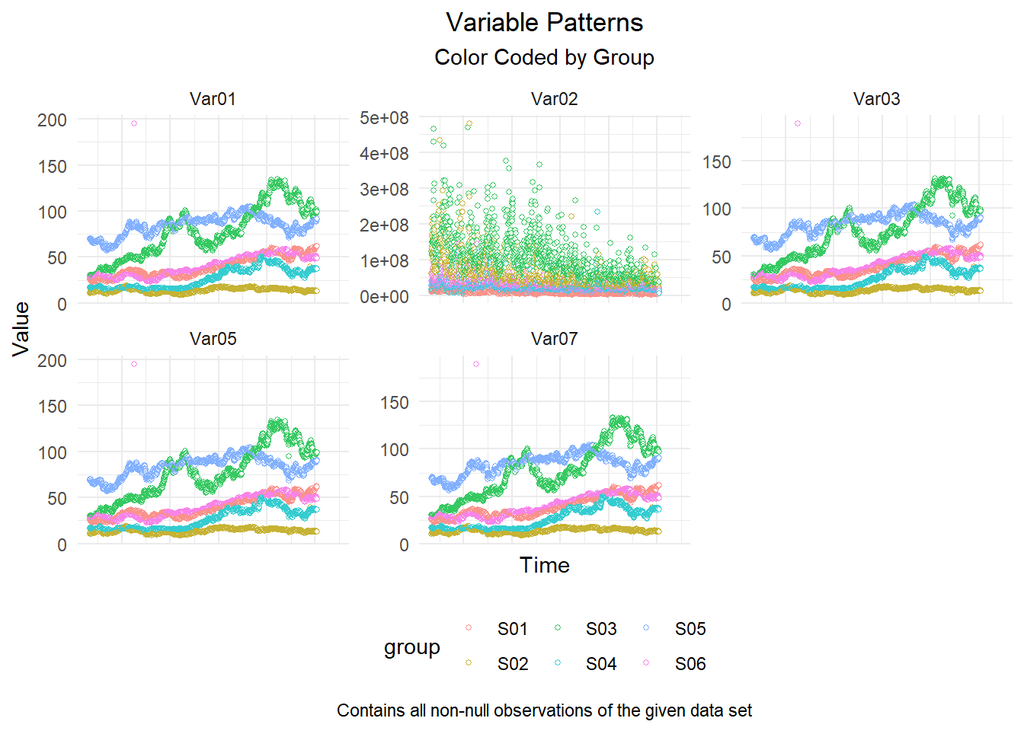

```r
data[c(1:7)]%>%
  gather(variable, value, -SeriesInd, -group) %>%
  ggplot(., aes(value, SeriesInd, color = group)) +
  geom_point(fill = "white",
             size=1,
             shape=21,
             alpha = 0.75) +
  coord_flip() +
   facet_wrap(~variable,
             scales ="free") +
  labs(title = "Variable Patterns",
       subtitle = "Color Coded by Group",
       x="Value",
       y="Time",
       caption = "Contains all non-null observations of the given data set") +
  theme_minimal() +
  theme(plot.title = element_text(hjust=0.5),
        plot.subtitle = element_text(hjust=0.5),
        legend.position = "bottom",
        axis.ticks.x=element_blank(),
        axis.text.x=element_blank(),
        plot.caption = element_text(hjust=0.5)
        )
```

Seasonality was also considered. It is possible this data follows a weak seasonal trend that increases during summer months but there is not a lot of evidence to support regular fluctuations. Regular gaps were noticed in the time series on a weekly basis and several methods were used in attempts to fix this. However, the data appears randomly distributed and as such, acts randomly. For this reason, we left the gaps alone and any further adjustments made were minimal to avoid disturbing any existing patterns in the data.

```r
# ndiffs(ts_S01_Var01)
# ts_S01_Var01%>%diff()%>%ndiffs()
# ndiffs test for ts_S01_Var02.
# ndiffs(ts_S01_Var02)
# ts_S01_Var02%>%diff()%>%ndiffs()
# ndiffs test for ts_S02_Var02
# ndiffs(ts_S02_Var02)
# ts_S02_Var02%>%diff()%>%ndiffs()
# ndiffs test for ts_S02_Var03.
# ndiffs(ts_S02_Var03)
# ts_S02_Var02%>%diff()%>%ndiffs()
# ndiffs test for ts_S03_Var05.
# ndiffs(ts_S03_Var05)
# ts_S03_Var05%>%diff()%>%ndiffs()
# ndiffs test for ts_S03_Var07.
# ndiffs(ts_S03_Var07)
# ts_S03_Var07%>%diff()%>%ndiffs()
# # According to the ndiffs test, all the variables above require difference.
```

## Prediction

```r
train0101<-window(ts_S01_Var01, end=as.integer(length(ts_S01_Var01)*0.7))
train0102<-window(ts_S01_Var02, end=as.integer(length(ts_S01_Var02)*0.7))
train0202<-window(ts_S02_Var02, end=as.integer(length(ts_S02_Var02)*0.7))
train0203<-window(ts_S02_Var03, end=as.integer(length(ts_S02_Var03)*0.7))
train0305<-window(ts_S03_Var05, end=as.integer(length(ts_S03_Var05)*0.7))
train0307<-window(ts_S03_Var07, end=as.integer(length(ts_S03_Var07)*0.7))
length(ts_S01_Var01)*0.3
```

```
## [1] 487.5
```

```r
library(dplyr)
library(forecast)
AA_fit0101 <- train0101 %>% auto.arima(stepwise = FALSE, approximation =FALSE, seasonal = TRUE) %>% forecast(h=488)
AA_fit0102 <- train0102 %>% auto.arima(stepwise = FALSE, approximation =FALSE, seasonal = TRUE) %>% forecast(h=488)
AA_fit0202 <- train0202 %>% auto.arima(stepwise = FALSE, approximation =FALSE, seasonal = TRUE) %>% forecast(h=488)
AA_fit0203 <- train0203 %>% auto.arima(stepwise = FALSE, approximation =FALSE, seasonal = TRUE) %>% forecast(h=488)
AA_fit0305 <- train0305 %>% auto.arima(stepwise = FALSE, approximation =FALSE, seasonal = TRUE) %>% forecast(h=488)
AA_fit0307 <- train0307 %>% auto.arima(stepwise = FALSE, approximation =FALSE, seasonal = TRUE) %>% forecast(h=488)



mape0101<-accuracy(AA_fit0101,ts_S01_Var01)["Test set", "MAPE"]
mape0101
```

```
## [1] 5.7693
```

```r
mape0102<-accuracy(AA_fit0102,ts_S01_Var02)["Test set","MAPE"]
mape0102
```

```
## [1] 30.40054
```

```r
mape0202<-accuracy(AA_fit0202,ts_S02_Var02)["Test set", "MAPE"]
mape0202
```

```
## [1] 78.81883
```

```r
mape0203<-accuracy(AA_fit0203,ts_S02_Var03)["Test set", "MAPE"]
mape0203
```

```
## [1] 19.28435
```

```r
mape0305<-accuracy(AA_fit0305,ts_S03_Var05)["Test set", "MAPE"]
mape0101
```

```
## [1] 5.7693
```

```r
mape0307<-accuracy(AA_fit0307,ts_S03_Var07)["Test set", "MAPE"]
mape0307
```

```
## [1] 11.09277
```

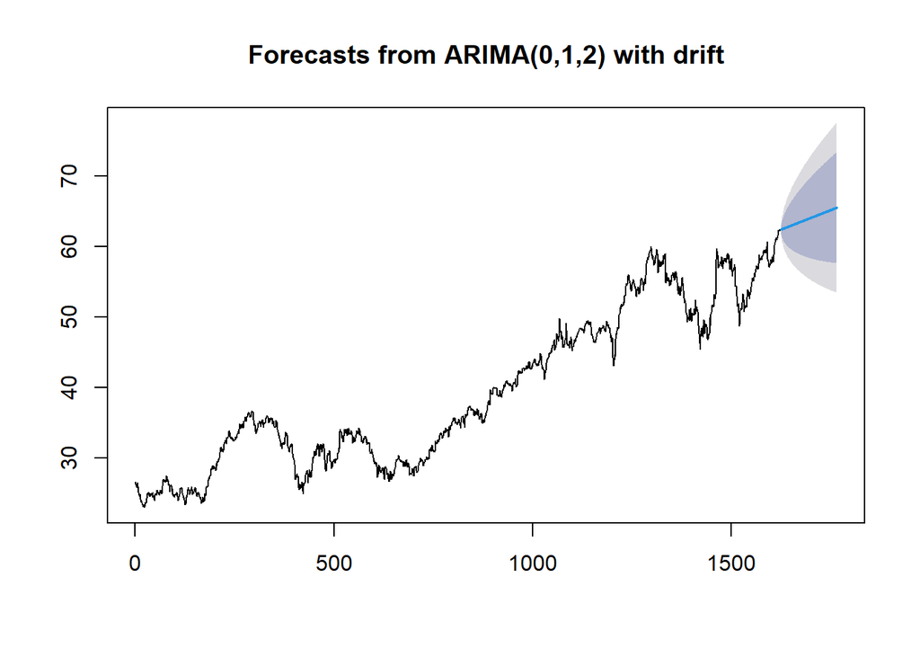

```r
AA0101<-auto.arima(ts_S01_Var01, stepwise = F, approximation = F, seasonal = T)
fcast0101<-forecast(AA0101,h=140)
plot(fcast0101)
```

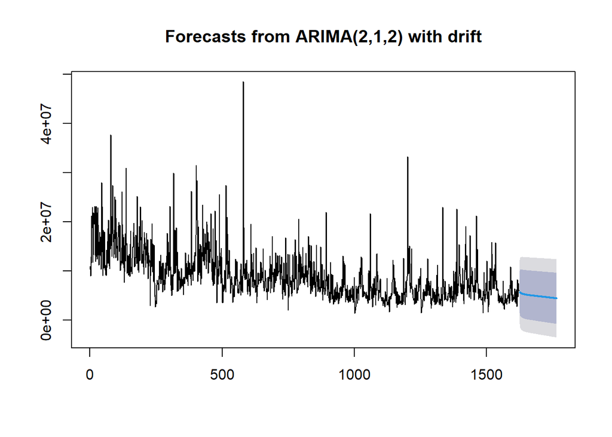

```r
AA0102<-auto.arima(ts_S01_Var02, stepwise = F, approximation = F, seasonal = T)
fcast0102<-forecast(AA0102,h=140)
plot(fcast0102)
```

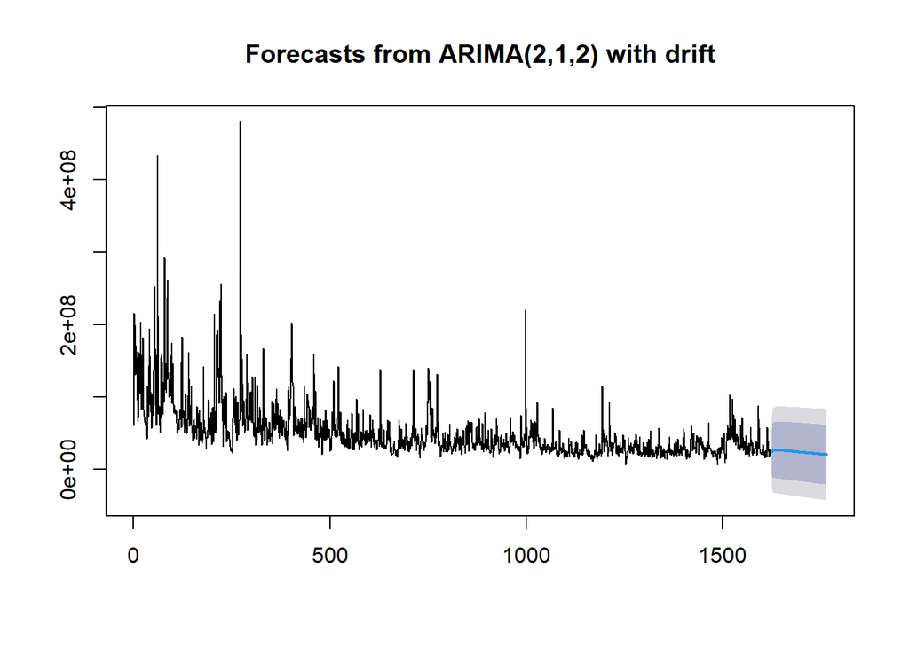

```r
AA0202<-auto.arima(ts_S02_Var02, stepwise = F, approximation = F, seasonal = T)
fcast0202<-forecast(AA0202,h=140)
plot(fcast0202)
```

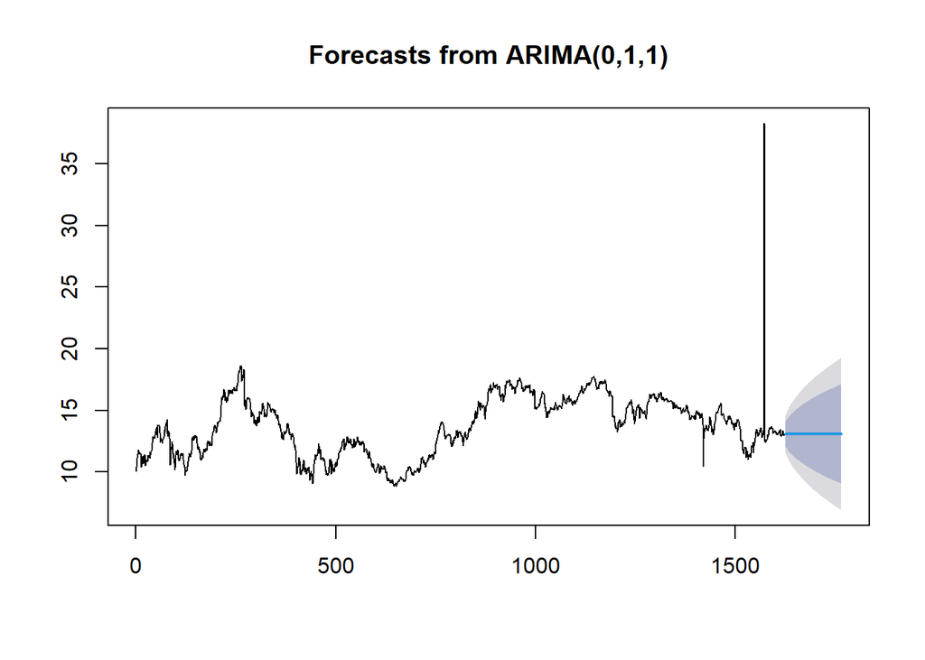

```r
AA0203<-auto.arima(ts_S02_Var03, stepwise = F, approximation = F, seasonal = T)
fcast0203<-forecast(AA0203,h=140)
plot(fcast0203)
```

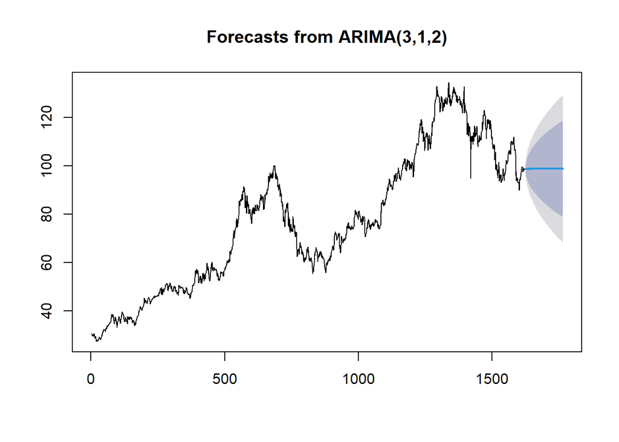

```r
AA0305<-auto.arima(ts_S03_Var05, stepwise = F, approximation = F, seasonal = T)
fcast0305<-forecast(AA0305,h=140)
plot(fcast0305)
```

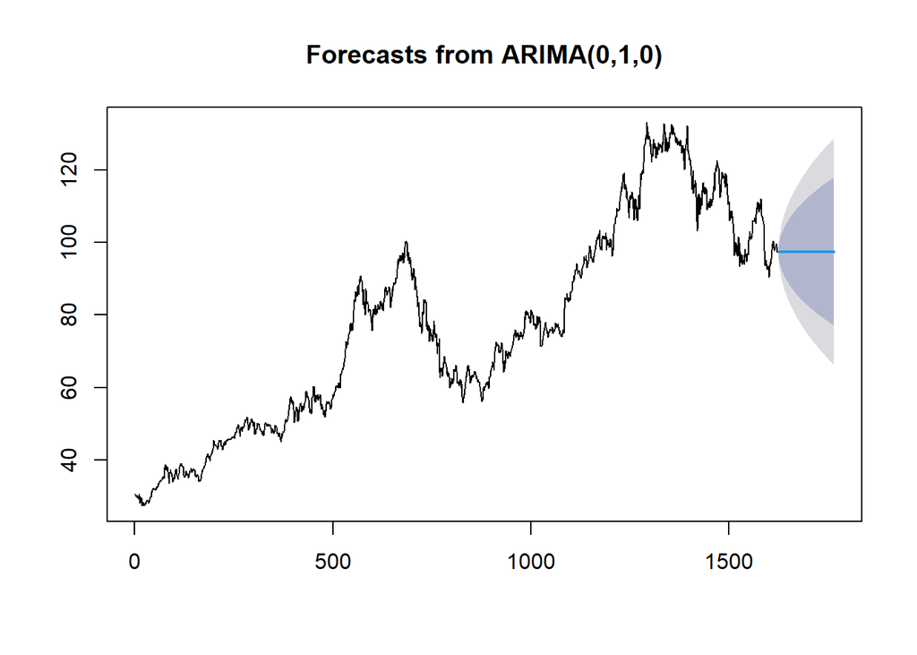

```r
AA0307<-auto.arima(ts_S03_Var07, stepwise = F, approximation = F, seasonal = T)
fcast0307<-forecast(AA0307,h=140)
plot(fcast0307)
```

```r
fcast0101
```

```
##      Point Forecast    Lo 80    Hi 80    Lo 95    Hi 95
## 1626       62.39704 61.74274 63.05135 61.39637 63.39772
## 1627       62.41922 61.45258 63.38587 60.94086 63.89758
## 1628       62.44125 61.26868 63.61382 60.64795 64.23454
## 1629       62.46327 61.11589 63.81065 60.40263 64.52392
## 1630       62.48530 60.98331 63.98728 60.18821 64.78238
## 1631       62.50732 60.86523 64.14942 59.99596 65.01869
## 1632       62.52935 60.75819 64.30050 59.82060 65.23809
## 1633       62.55137 60.65994 64.44280 59.65868 65.44406
## 1634       62.57340 60.56890 64.57790 59.50778 65.63901
## 1635       62.59542 60.48390 64.70695 59.36612 65.82472
## 1636       62.61745 60.40407 64.83083 59.23237 66.00252
## 1637       62.63947 60.32872 64.95022 59.10548 66.17346
## 1638       62.66150 60.25732 65.06568 58.98462 66.33837
## 1639       62.68352 60.18941 65.17763 58.86910 66.49794
```

[output cut: 126 more lines]

```r
fcast0102
```

```
##      Point Forecast       Lo 80    Hi 80      Lo 95    Hi 95
## 1626        5743772 1504215.083  9983329  -740070.7 12227615
## 1627        5636139 1087600.319 10184677 -1320250.4 12592527
## 1628        5577761  929998.521 10225524 -1530378.5 12685901
## 1629        5534519  828946.217 10240091 -1662033.4 12731071
## 1630        5497692  749190.107 10246193 -1764514.7 12759898
## 1631        5464837  681814.076 10247859 -1850165.2 12779839
## 1632        5435087  623542.207 10246631 -1923535.6 12793709
## 1633        5407990  572592.367 10243388 -1987112.7 12803093
## 1634        5383225  527714.803 10238736 -2042637.2 12809088
## 1635        5360525  487934.056 10233116 -2091459.9 12812510
## 1636        5339657  452459.011 10226856 -2134667.6 12813982
## 1637        5320417  420638.335 10220196 -2173147.8 12813982
## 1638        5302622  391931.556 10213312 -2207630.8 12812874
## 1639        5286111  365887.695 10206333 -2238720.9 12810942
```

[output cut: 126 more lines]

```r
fcast0202
```

```
##      Point Forecast     Lo 80    Hi 80     Lo 95    Hi 95
## 1626       24510562  -7744678 56765803 -24819571 73840695
## 1627       25459984 -10852111 61772079 -30074573 80994542
## 1628       25920865 -11633627 63475357 -31513774 83355504
## 1629       26157614 -11915239 64230466 -32069790 84385017
## 1630       26288281 -12065931 64642494 -32369425 84945988
## 1631       26365940 -12174203 64906083 -32576123 85308002
## 1632       26414767 -12264725 65094260 -32740412 85569947
## 1633       26446063 -12345775 65237901 -32880933 85773060
## 1634       26465352 -12420851 65351556 -33005964 85936668
## 1635       26475543 -12491833 65442919 -33119916 86071002
## 1636       26478335 -12559926 65516595 -33225533 86182202
## 1637       26474846 -12625986 65575678 -33324716 86274408
## 1638       26465898 -12690648 65622445 -33418872 86350669
## 1639       26452146 -12754391 65658682 -33509078 86413369
```

[output cut: 126 more lines]

```r
fcast0203
```

```
##      Point Forecast     Lo 80    Hi 80     Lo 95    Hi 95
## 1626       13.07911 12.081253 14.07697 11.553019 14.60520
## 1627       13.07911 12.028014 14.13021 11.471598 14.68662
## 1628       13.07911 11.977345 14.18087 11.394106 14.76411
## 1629       13.07911 11.928906 14.22931 11.320025 14.83820
## 1630       13.07911 11.882426 14.27579 11.248940 14.90928
## 1631       13.07911 11.837685 14.32053 11.180515 14.97771
## 1632       13.07911 11.794502 14.36372 11.114471 15.04375
## 1633       13.07911 11.752723 14.40550 11.050576 15.10764
## 1634       13.07911 11.712221 14.44600 10.988634 15.16959
## 1635       13.07911 11.672885 14.48534 10.928474 15.22975
## 1636       13.07911 11.634620 14.52360 10.869953 15.28827
## 1637       13.07911 11.597342 14.56088 10.812942 15.34528
## 1638       13.07911 11.560980 14.59724 10.757331 15.40089
## 1639       13.07911 11.525468 14.63275 10.703020 15.45520
```

[output cut: 126 more lines]

```r
fcast0305
```

```
##      Point Forecast    Lo 80    Hi 80    Lo 95    Hi 95
## 1626       98.86793 96.95649 100.7794 95.94463 101.7912
## 1627       98.98513 96.48601 101.4843 95.16305 102.8072
## 1628       98.82444 95.79562 101.8533 94.19225 103.4566
## 1629       98.81411 95.33921 102.2890 93.49971 104.1285
## 1630       98.97102 95.12694 102.8151 93.09201 104.8500
## 1631       98.88669 94.69043 103.0830 92.46906 105.3043
## 1632       98.78962 94.25608 103.3232 91.85617 105.7231
## 1633       98.92720 94.09955 103.7548 91.54394 106.3104
## 1634       98.93601 93.83026 104.0418 91.12745 106.7446
## 1635       98.80128 93.41562 104.1869 90.56462 107.0379
## 1636       98.87380 93.23216 104.5154 90.24566 107.5019
## 1637       98.95707 93.07863 104.8355 89.96677 107.9474
## 1638       98.83889 92.71948 104.9583 89.48006 108.1977
## 1639       98.83142 92.48083 105.1820 89.11903 108.5438
```

[output cut: 126 more lines]

```r
fcast0307
```

```
##      Point Forecast    Lo 80     Hi 80    Lo 95    Hi 95
## 1626       97.46326 95.74322  99.18330 94.83268 100.0938
## 1627       97.46326 95.03075  99.89576 93.74307 101.1835
## 1628       97.46326 94.48406 100.44245 92.90697 102.0195
## 1629       97.46326 94.02318 100.90334 92.20211 102.7244
## 1630       97.46326 93.61713 101.30938 91.58112 103.3454
## 1631       97.46326 93.25004 101.67648 91.01969 103.9068
## 1632       97.46326 92.91246 102.01406 90.50341 104.4231
## 1633       97.46326 92.59825 102.32827 90.02287 104.9036
## 1634       97.46326 92.30314 102.62338 89.57154 105.3550
## 1635       97.46326 92.02401 102.90250 89.14465 105.7819
## 1636       97.46326 91.75853 103.16799 88.73863 106.1879
## 1637       97.46326 91.50487 103.42165 88.35068 106.5758
## 1638       97.46326 91.26157 103.66495 87.97859 106.9479
## 1639       97.46326 91.02746 103.89906 87.62055 107.3060
```

[output cut: 126 more lines]

```r
S0101 <- fcast0101$mean
S0102 <- fcast0102$mean
S0202 <- fcast0202$mean
S0203 <- fcast0203$mean
S0305 <- fcast0305$mean
S0307 <- fcast0307$mean
S0101_preds <- S0101[1:140]
S0102_preds <- S0102[1:140]
S0202_preds <- S0202[1:140]
S0203_preds <- S0203[1:140]
S0305_preds <- S0305[1:140]
S0307_preds <- S0307[1:140]
csv <- data.frame(cbind(S0101_preds, S0102_preds, S0202_preds, S0203_preds,S0305_preds, S0307_preds))
# write.csv(csv, file = "C:/data/csv.csv")
```

To evaluate our models we split the data into training and testing data sets with 70% reserved for training and 30% set aside for testing. We use the training data to build our models to forecast the proper variables in each group. We repeat the cleaning performed in the analysis and forecast the values with our ARIMA model method. These predicted values are then compared with the testing data to see if they agree using mean absolute percentage error (MAPE). Predicted values that differ from expectations increase the amount of error. Three groups are selected to visualize major trends.

```r
library(readxl)
library(dplyr)
library(forecast)
library(fma)
library(tsoutliers)
```

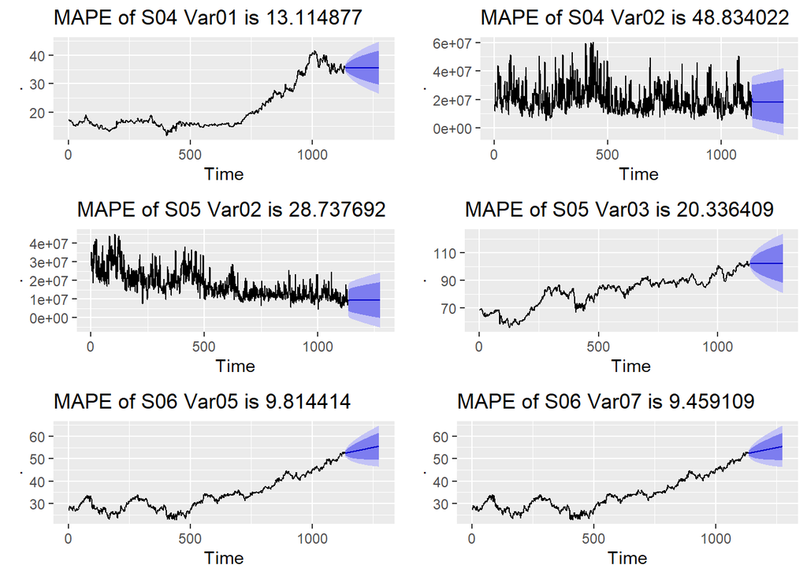

```r
library(tidyverse)
# setwd("C:/Users/Zachary.Palmore/GitHub/msds/Predictive Analytics/Projects/Project1")
data <- read_excel("data.xlsx", sheet="S04", skip=2)
df.1 <- data %>%
          select(c('SeriesInd', 'Var01')) %>%
          filter(SeriesInd<= 43021)  %>%
          rename(ts = Var01)
df.2 <- data %>%
          select(c('SeriesInd', 'Var02')) %>%
          filter(SeriesInd<= 43021)  %>%
          rename(ts = Var02)
data <- read_excel("data.xlsx", sheet="S05", skip=2)
df.3 <- data %>%
          select(c('SeriesInd', 'Var02')) %>%
          filter(SeriesInd<= 43021)  %>%
          rename(ts = Var02)
df.4 <- data %>%
          select(c('SeriesInd', 'Var03')) %>%
          filter(SeriesInd<= 43021)  %>%
          rename(ts = Var03)
data <- read_excel("data.xlsx", sheet="S06", skip=2)
df.5 <- data %>%
          select(c('SeriesInd', 'Var05')) %>%
          filter(SeriesInd<= 43021)  %>%
          rename(ts = Var05)
df.6 <- data %>%
          select(c('SeriesInd', 'Var07')) %>%
          filter(SeriesInd<= 43021) %>%
          rename(ts = Var07)
all_df <- list(df.1, df.2, df.3, df.4, df.5, df.6)

build_model <- function(train) {
  model <- train %>%
              tsclean() %>%
              auto.arima()
  return(model)
}
create_plot <- function(model, test, var){
  predict1 <- forecast(model, h=488)
  mape <- accuracy(predict1, test)["Test set", "MAPE"]
  title <- sprintf("MAPE of %s is %f" , var, mape)
  predict2 <- forecast(model, h=140)
  return(autoplot(predict2, main=title))
}
iterate <- function(df_list){
  variables <- list("S04 Var01", "S04 Var02", "S05 Var02", "S05 Var03", "S06 Var05", "S06 Var07")
  plot_list = list()
  i <- 1
  for (x in df_list){
    train <- window(x$ts, end=1135)
    test <- window(x$ts, start=1136)
    model <- build_model(train)
    plot_list[[i]] <- create_plot(model, test, variables[i])
    i <- i + 1
  }
return(gridExtra::grid.arrange(grobs = plot_list))
}

iterate(all_df)
```